# DESCRIPTIVE ABSTRACT

Ames Iowa: Alternative to the Boston Housing Data Set:  
Order (Discrete): Observation number

*PID (Nominal): Parcel identification number - can be used with city web site for parcel review.

*MS SubClass (Nominal): Identifies the type of dwelling involved in the sale.

```
   020  1-STORY 1946 & NEWER ALL STYLES
   030  1-STORY 1945 & OLDER
   040  1-STORY W/FINISHED ATTIC ALL AGES
   045  1-1/2 STORY - UNFINISHED ALL AGES
   050  1-1/2 STORY FINISHED ALL AGES
   060  2-STORY 1946 & NEWER
   070  2-STORY 1945 & OLDER
   075  2-1/2 STORY ALL AGES
   080  SPLIT OR MULTI-LEVEL
   085  SPLIT FOYER
   090  DUPLEX - ALL STYLES AND AGES
   120  1-STORY PUD (Planned Unit Development) - 1946 & NEWER
   150  1-1/2 STORY PUD - ALL AGES
   160  2-STORY PUD - 1946 & NEWER
   180  PUD - MULTILEVEL - INCL SPLIT LEV/FOYER
   190  2 FAMILY CONVERSION - ALL STYLES AND AGES
```

*MS Zoning (Nominal): Identifies the general zoning classification of the sale.

```
   A    Agriculture
   C    Commercial
   FV   Floating Village Residential
   I    Industrial
   RH   Residential High Density
   RL   Residential Low Density
   RP   Residential Low Density Park
   RM   Residential Medium Density
```

*Lot Frontage (Continuous): Linear feet of street connected to property

*Lot Area (Continuous): Lot size in square feet

*Street (Nominal): Type of road access to property

```
   Grvl Gravel
   Pave Paved
```

*Alley (Nominal): Type of alley access to property

```
   Grvl Gravel
   Pave Paved
   NA   No alley access
```

*Lot Shape (Ordinal): General shape of property

```
   Reg  Regular
   IR1  Slightly irregular
   IR2  Moderately Irregular
   IR3  Irregular
```

*Land Contour (Nominal): Flatness of the property

```
   Lvl  Near Flat/Level
   Bnk  Banked - Quick and significant rise from street grade to *building
   HLS  Hillside - Significant slope from side to side
   Low  Depression
```

*Utilities (Ordinal): Type of utilities available

```
   AllPub   All public Utilities (E,G,W,& S)
   NoSewr   Electricity, Gas, and Water (Septic Tank)
   NoSeWa   Electricity and Gas Only
   ELO  Electricity only
```

*Lot Config (Nominal): Lot configuration

```
   Inside   Inside lot
   Corner   Corner lot
   CulDSac  Cul-de-sac
   FR2  Frontage on 2 sides of property
   FR3  Frontage on 3 sides of property
```

*Land Slope (Ordinal): Slope of property

```
   Gtl  Gentle slope
   Mod  Moderate Slope
   Sev  Severe Slope
```

*Neighborhood (Nominal): Physical locations within Ames city limits (map available)

```
   Blmngtn  Bloomington Heights
   Blueste  Bluestem
   BrDale   Briardale
   BrkSide  Brookside
   ClearCr  Clear Creek
   CollgCr  College Creek
   Crawfor  Crawford
   Edwards  Edwards
   Gilbert  Gilbert
   Greens   Greens
   GrnHill  Green Hills
   IDOTRR   Iowa DOT and Rail Road
   Landmrk  Landmark
   MeadowV  Meadow Village
   Mitchel  Mitchell
   Names    North Ames
   NoRidge  Northridge
   NPkVill  Northpark Villa
   NridgHt  Northridge Heights
   NWAmes   Northwest Ames
   OldTown  Old Town
   SWISU    South & West of Iowa State University
   Sawyer   Sawyer
   SawyerW  Sawyer West
   Somerst  Somerset
   StoneBr  Stone Brook
   Timber   Timberland
   Veenker  Veenker
```

*Condition 1 (Nominal): Proximity to various conditions

```
   Artery   Adjacent to arterial street
   Feedr    Adjacent to feeder street
   Norm Normal
   RRNn Within 200' of North-South Railroad
   RRAn Adjacent to North-South Railroad
   PosN Near positive off-site feature--park, greenbelt, etc.
   PosA Adjacent to postive off-site feature
   RRNe Within 200' of East-West Railroad
   RRAe Adjacent to East-West Railroad
```

*Condition 2 (Nominal): Proximity to various conditions (if more than one is present)

```
   Artery   Adjacent to arterial street
   Feedr    Adjacent to feeder street
   Norm Normal
   RRNn Within 200' of North-South Railroad
   RRAn Adjacent to North-South Railroad
   PosN Near positive off-site feature--park, greenbelt, etc.
   PosA Adjacent to postive off-site feature
   RRNe Within 200' of East-West Railroad
   RRAe Adjacent to East-West Railroad
```

*Bldg Type (Nominal): Type of dwelling

```
   1Fam Single-family Detached
   2FmCon   Two-family Conversion; originally built as one-family *dwelling
   Duplx    Duplex
   TwnhsE   Townhouse End Unit
   TwnhsI   Townhouse Inside Unit
```

*House Style (Nominal): Style of dwelling

```
   1Story   One story
   1.5Fin   One and one-half story: 2nd level finished
   1.5Unf   One and one-half story: 2nd level unfinished
   2Story   Two story
   2.5Fin   Two and one-half story: 2nd level finished
   2.5Unf   Two and one-half story: 2nd level unfinished
   SFoyer   Split Foyer
   SLvl Split Level
```

*Overall Qual (Ordinal): Rates the overall material and finish of the house

```
   10   Very Excellent
   9    Excellent
   8    Very Good
   7    Good
   6    Above Average
   5    Average
   4    Below Average
   3    Fair
   2    Poor
   1    Very Poor
```

*Overall Cond (Ordinal): Rates the overall condition of the house

```
   10   Very Excellent
   9    Excellent
   8    Very Good
   7    Good
   6    Above Average
   5    Average
   4    Below Average
   3    Fair
   2    Poor
   1    Very Poor
```

*Year Built (Discrete): Original construction date

*Year Remod/Add (Discrete): Remodel date (same as construction date if no remodeling or additions)

*Roof Style (Nominal): Type of roof

```
   Flat Flat
   Gable    Gable
   Gambrel  Gabrel (Barn)
   Hip  Hip
   Mansard  Mansard
   Shed Shed
```

*Roof Matl (Nominal): Roof material

```
   ClyTile  Clay or Tile
   CompShg  Standard (Composite) Shingle
   Membran  Membrane
   Metal    Metal
   Roll Roll
   Tar&Grv  Gravel & Tar
   WdShake  Wood Shakes
   WdShngl  Wood Shingles
```

*Exterior 1 (Nominal): Exterior covering on house

```
   AsbShng  Asbestos Shingles
   AsphShn  Asphalt Shingles
   BrkComm  Brick Common
   BrkFace  Brick Face
   CBlock   Cinder Block
   CemntBd  Cement Board
   HdBoard  Hard Board
   ImStucc  Imitation Stucco
   MetalSd  Metal Siding
   Other    Other
   Plywood  Plywood
   PreCast  PreCast
   Stone    Stone
   Stucco   Stucco
   VinylSd  Vinyl Siding
   Wd Sdng  Wood Siding
   WdShing  Wood Shingles
```

*Exterior 2 (Nominal): Exterior covering on house (if more than one material)

```
   AsbShng  Asbestos Shingles
   AsphShn  Asphalt Shingles
   BrkComm  Brick Common
   BrkFace  Brick Face
   CBlock   Cinder Block
   CemntBd  Cement Board
   HdBoard  Hard Board
   ImStucc  Imitation Stucco
   MetalSd  Metal Siding
   Other    Other
   Plywood  Plywood
   PreCast  PreCast
   Stone    Stone
   Stucco   Stucco
   VinylSd  Vinyl Siding
   Wd Sdng  Wood Siding
   WdShing  Wood Shingles
```

*Mas Vnr Type (Nominal): Masonry veneer type

```
   BrkCmn   Brick Common
   BrkFace  Brick Face
   CBlock   Cinder Block
   None None
   Stone    Stone
```

*Mas Vnr Area (Continuous): Masonry veneer area in square feet

*Exter Qual (Ordinal): Evaluates the quality of the material on the exterior

```
   Ex   Excellent
   Gd   Good
   TA   Average/Typical
   Fa   Fair
   Po   Poor
```

*Exter Cond (Ordinal): Evaluates the present condition of the material on the exterior

```
   Ex   Excellent
   Gd   Good
   TA   Average/Typical
   Fa   Fair
   Po   Poor
```

*Foundation (Nominal): Type of foundation

```
   BrkTil   Brick & Tile
   CBlock   Cinder Block
   PConc    Poured Contrete
   Slab Slab
   Stone    Stone
   Wood Wood
```

*Bsmt Qual (Ordinal): Evaluates the height of the basement

```
   Ex   Excellent (100+ inches)
   Gd   Good (90-99 inches)
   TA   Typical (80-89 inches)
   Fa   Fair (70-79 inches)
   Po   Poor (<70 inches
   NA   No Basement)
```

*Bsmt Cond (Ordinal): Evaluates the general condition of the basement

```
   Ex   Excellent
   Gd   Good
   TA   Typical - slight dampness allowed
   Fa   Fair - dampness or some cracking or settling
   Po   Poor - Severe cracking, settling, or wetness
   NA   No Basement
```

*Bsmt Exposure (Ordinal): Refers to walkout or garden level walls

```
   Gd   Good Exposure
   Av   Average Exposure (split levels or foyers typically score average or above)
   Mn   Mimimum Exposure
   No   No Exposure
   NA   No Basement
```

*BsmtFin Type 1 (Ordinal): Rating of basement finished area

```
   GLQ  Good Living Quarters
   ALQ  Average Living Quarters
   BLQ  Below Average Living Quarters
   Rec  Average Rec Room
   LwQ  Low Quality
   Unf  Unfinshed
   NA   No Basement
```

*BsmtFin SF 1 (Continuous): Type 1 finished square feet

*BsmtFinType 2 (Ordinal): Rating of basement finished area (if multiple types)

```
   GLQ  Good Living Quarters
   ALQ  Average Living Quarters
   BLQ  Below Average Living Quarters
   Rec  Average Rec Room
   LwQ  Low Quality
   Unf  Unfinshed
   NA   No Basement
```

*BsmtFin SF 2 (Continuous): Type 2 finished square feet

*Bsmt Unf SF (Continuous): Unfinished square feet of basement area

*Total Bsmt SF (Continuous): Total square feet of basement area

*Heating (Nominal): Type of heating

```
   Floor    Floor Furnace
   GasA Gas forced warm air furnace
   GasW Gas hot water or steam heat
   Grav Gravity furnace
   OthW Hot water or steam heat other than gas
   Wall Wall furnace
```

*HeatingQC (Ordinal): Heating quality and condition

```
   Ex   Excellent
   Gd   Good
   TA   Average/Typical
   Fa   Fair
   Po   Poor
```

*Central Air (Nominal): Central air conditioning

```
   N    No
   Y    Yes
```

*Electrical (Ordinal): Electrical system

```
   SBrkr    Standard Circuit Breakers & Romex
   FuseA    Fuse Box over 60 AMP and all Romex wiring (Average)
   FuseF    60 AMP Fuse Box and mostly Romex wiring (Fair)
   FuseP    60 AMP Fuse Box and mostly knob & tube wiring (poor)
   Mix  Mixed
```

*1st Flr SF (Continuous): First Floor square feet

*2nd Flr SF (Continuous) : Second floor square feet

*Low Qual Fin SF (Continuous): Low quality finished square feet (all floors)

*Gr Liv Area (Continuous): Above grade (ground) living area square feet

*Bsmt Full Bath (Discrete): Basement full bathrooms

*Bsmt Half Bath (Discrete): Basement half bathrooms

*Full Bath (Discrete): Full bathrooms above grade

*Half Bath (Discrete): Half baths above grade

*Bedroom (Discrete): Bedrooms above grade (does NOT include basement bedrooms)

*Kitchen (Discrete): Kitchens above grade

*KitchenQual (Ordinal): Kitchen quality

```
   Ex   Excellent
   Gd   Good
   TA   Typical/Average
   Fa   Fair
   Po   Poor
```

*TotRmsAbvGrd (Discrete): Total rooms above grade (does not include bathrooms)

*Functional (Ordinal): Home functionality (Assume typical unless deductions are warranted)

```
   Typ  Typical Functionality
   Min1 Minor Deductions 1
   Min2 Minor Deductions 2
   Mod  Moderate Deductions
   Maj1 Major Deductions 1
   Maj2 Major Deductions 2
   Sev  Severely Damaged
   Sal  Salvage only
```

*Fireplaces (Discrete): Number of fireplaces

*FireplaceQu (Ordinal): Fireplace quality

```
   Ex   Excellent - Exceptional Masonry Fireplace
   Gd   Good - Masonry Fireplace in main level
   TA   Average - Prefabricated Fireplace in main living area or *Masonry Fireplace in basement
   Fa   Fair - Prefabricated Fireplace in basement
   Po   Poor - Ben Franklin Stove
   NA   No Fireplace
```

*Garage Type (Nominal): Garage location

```
   2Types   More than one type of garage
   Attchd   Attached to home
   Basment  Basement Garage
   BuiltIn  Built-In (Garage part of house - typically has room above garage)
   CarPort  Car Port
   Detchd   Detached from home
   NA   No Garage
```

*Garage Yr Blt (Discrete): Year garage was built

*Garage Finish (Ordinal) : Interior finish of the garage

```
   Fin  Finished
   RFn  Rough Finished
   Unf  Unfinished
   NA   No Garage
```

*Garage Cars (Discrete): Size of garage in car capacity

*Garage Area (Continuous): Size of garage in square feet

*Garage Qual (Ordinal): Garage quality

```
   Ex   Excellent
   Gd   Good
   TA   Typical/Average
   Fa   Fair
   Po   Poor
   NA   No Garage
```

*Garage Cond (Ordinal): Garage condition

```
   Ex   Excellent
   Gd   Good
   TA   Typical/Average
   Fa   Fair
   Po   Poor
   NA   No Garage
```

*Paved Drive (Ordinal): Paved driveway

```
   Y    Paved
   P    Partial Pavement
   N    Dirt/Gravel
```

*Wood Deck SF (Continuous): Wood deck area in square feet

*Open Porch SF (Continuous): Open porch area in square feet

*Enclosed Porch (Continuous): Enclosed porch area in square feet

*3-Ssn Porch (Continuous): Three season porch area in square feet

*Screen Porch (Continuous): Screen porch area in square feet

*Pool Area (Continuous): Pool area in square feet

*Pool QC (Ordinal): Pool quality

```
   Ex   Excellent
   Gd   Good
   TA   Average/Typical
   Fa   Fair
   NA   No Pool
```

*Fence (Ordinal): Fence quality

```
   GdPrv    Good Privacy
   MnPrv    Minimum Privacy
   GdWo Good Wood
   MnWw Minimum Wood/Wire
   NA   No Fence
```

*Misc Feature (Nominal): Miscellaneous feature not covered in other categories

```
   Elev Elevator
   Gar2 2nd Garage (if not described in garage section)
   Othr Other
   Shed Shed (over 100 SF)
   TenC Tennis Court
   NA   None
```

*Misc Val (Continuous): $Value of miscellaneous feature

*Mo Sold (Discrete): Month Sold (MM)

*Yr Sold (Discrete): Year Sold (YYYY)

*Sale Type (Nominal): Type of sale

```
   WD   Warranty Deed - Conventional
   CWD  Warranty Deed - Cash
   VWD  Warranty Deed - VA Loan
   New  Home just constructed and sold
   COD  Court Officer Deed/Estate
   Con  Contract 15% Down payment regular terms
   ConLw    Contract Low Down payment and low interest
   ConLI    Contract Low Interest
   ConLD    Contract Low Down
   Oth  Other
```

*Sale Condition (Nominal): Condition of sale

```
   Normal   Normal Sale
   Abnorml  Abnormal Sale -  trade, foreclosure, short sale
   AdjLand  Adjoining Land Purchase
   Alloca   Allocation - two linked properties with separate deeds, typically condo with a garage unit
   Family   Sale between family members
   Partial  Home was not completed when last assessed (associated with New Homes)
```

*SalePrice (Continuous): Sale price $$

# **Libraries**

```python
import pandas as pd
import numpy as np
import seaborn as sns
import matplotlib.pyplot as plt
```

# Dataset Link

**https://drive.google.com/file/d/15FRYmuKHP8-sqRzUeCfSGr4bJaXoly7l/view?usp=sharing**

```python
dataset=pd.read_csv('/content/AmesHousing.txt' , sep='\t')
print(dataset)
```

```
      Order        PID  MS SubClass MS Zoning  Lot Frontage  Lot Area Street  \
0         1  526301100           20        RL         141.0     31770   Pave
1         2  526350040           20        RH          80.0     11622   Pave
2         3  526351010           20        RL          81.0     14267   Pave
3         4  526353030           20        RL          93.0     11160   Pave
4         5  527105010           60        RL          74.0     13830   Pave
...     ...        ...          ...       ...           ...       ...    ...
2925   2926  923275080           80        RL          37.0      7937   Pave
2926   2927  923276100           20        RL           NaN      8885   Pave
2927   2928  923400125           85        RL          62.0     10441   Pave
2928   2929  924100070           20        RL          77.0     10010   Pave
2929   2930  924151050           60        RL          74.0      9627   Pave

     Alley Lot Shape Land Contour  ... Pool Area Pool QC  Fence Misc Feature  \
0      NaN       IR1          Lvl  ...         0     NaN    NaN          NaN
```

[output cut: 25 more lines]

```python
#shape of Dataset
dataset.shape
```

```
(2930, 82)
```

```python
dataset.head()
```

|  | Order | PID | MS SubClass | MS Zoning | Lot Frontage | Lot Area | Street | Alley | Lot Shape | Land Contour | ... | Pool Area | Pool QC | Fence | Misc Feature | Misc Val | Mo Sold | Yr Sold | Sale Type | Sale Condition | SalePrice |
| --- | --- | --- | --- | --- | --- | --- | --- | --- | --- | --- | --- | --- | --- | --- | --- | --- | --- | --- | --- | --- | --- |
| 0 | 1 | 526301100 | 20 | RL | 141.0 | 31770 | Pave | NaN | IR1 | Lvl | ... | 0 | NaN | NaN | NaN | 0 | 5 | 2010 | WD | Normal | 215000 |
| 1 | 2 | 526350040 | 20 | RH | 80.0 | 11622 | Pave | NaN | Reg | Lvl | ... | 0 | NaN | MnPrv | NaN | 0 | 6 | 2010 | WD | Normal | 105000 |
| 2 | 3 | 526351010 | 20 | RL | 81.0 | 14267 | Pave | NaN | IR1 | Lvl | ... | 0 | NaN | NaN | Gar2 | 12500 | 6 | 2010 | WD | Normal | 172000 |
| 3 | 4 | 526353030 | 20 | RL | 93.0 | 11160 | Pave | NaN | Reg | Lvl | ... | 0 | NaN | NaN | NaN | 0 | 4 | 2010 | WD | Normal | 244000 |
| 4 | 5 | 527105010 | 60 | RL | 74.0 | 13830 | Pave | NaN | IR1 | Lvl | ... | 0 | NaN | MnPrv | NaN | 0 | 3 | 2010 | WD | Normal | 189900 |

5 rows × 82 columns

```python
dataset.tail()
```

|  | Order | PID | MS SubClass | MS Zoning | Lot Frontage | Lot Area | Street | Alley | Lot Shape | Land Contour | ... | Pool Area | Pool QC | Fence | Misc Feature | Misc Val | Mo Sold | Yr Sold | Sale Type | Sale Condition | SalePrice |
| --- | --- | --- | --- | --- | --- | --- | --- | --- | --- | --- | --- | --- | --- | --- | --- | --- | --- | --- | --- | --- | --- |
| 2925 | 2926 | 923275080 | 80 | RL | 37.0 | 7937 | Pave | NaN | IR1 | Lvl | ... | 0 | NaN | GdPrv | NaN | 0 | 3 | 2006 | WD | Normal | 142500 |
| 2926 | 2927 | 923276100 | 20 | RL | NaN | 8885 | Pave | NaN | IR1 | Low | ... | 0 | NaN | MnPrv | NaN | 0 | 6 | 2006 | WD | Normal | 131000 |
| 2927 | 2928 | 923400125 | 85 | RL | 62.0 | 10441 | Pave | NaN | Reg | Lvl | ... | 0 | NaN | MnPrv | Shed | 700 | 7 | 2006 | WD | Normal | 132000 |
| 2928 | 2929 | 924100070 | 20 | RL | 77.0 | 10010 | Pave | NaN | Reg | Lvl | ... | 0 | NaN | NaN | NaN | 0 | 4 | 2006 | WD | Normal | 170000 |
| 2929 | 2930 | 924151050 | 60 | RL | 74.0 | 9627 | Pave | NaN | Reg | Lvl | ... | 0 | NaN | NaN | NaN | 0 | 11 | 2006 | WD | Normal | 188000 |

5 rows × 82 columns

# Cleaning the Dataset

1)Checking unnecessary values like missing or null value  
2)Removing null values.  
3)Checking the unnecessary values After removing null values

```python
dataset.isnull().sum()
```

```
Order               0
PID                 0
MS SubClass         0
MS Zoning           0
Lot Frontage      490
                 ...
Mo Sold             0
Yr Sold             0
Sale Type           0
Sale Condition      0
SalePrice           0
Length: 82, dtype: int64
```

```python
#Remove the Unnecessary
df= dataset.dropna(axis=1)
print(df)
```

```
      Order        PID  MS SubClass MS Zoning  Lot Area Street Lot Shape  \
0         1  526301100           20        RL     31770   Pave       IR1
1         2  526350040           20        RH     11622   Pave       Reg
2         3  526351010           20        RL     14267   Pave       IR1
3         4  526353030           20        RL     11160   Pave       Reg
4         5  527105010           60        RL     13830   Pave       IR1
...     ...        ...          ...       ...       ...    ...       ...
2925   2926  923275080           80        RL      7937   Pave       IR1
2926   2927  923276100           20        RL      8885   Pave       IR1
2927   2928  923400125           85        RL     10441   Pave       Reg
2928   2929  924100070           20        RL     10010   Pave       Reg
2929   2930  924151050           60        RL      9627   Pave       Reg

     Land Contour Utilities Lot Config  ... Enclosed Porch 3Ssn Porch  \
0             Lvl    AllPub     Corner  ...              0          0
```

[output cut: 38 more lines]

```python
#Checking the unnecessary values After removing null values
df.isnull().sum()
```

```
Order              0
PID                0
MS SubClass        0
MS Zoning          0
Lot Area           0
Street             0
Lot Shape          0
Land Contour       0
Utilities          0
Lot Config         0
Land Slope         0
Neighborhood       0
Condition 1        0
Condition 2        0
Bldg Type          0
House Style        0
Overall Qual       0
Overall Cond       0
Year Built         0
Year Remod/Add     0
Roof Style         0
Roof Matl          0
Exterior 1st       0
Exterior 2nd       0
Exter Qual         0
Exter Cond         0
Foundation         0
Heating            0
Heating QC         0
Central Air        0
1st Flr SF         0
2nd Flr SF         0
Low Qual Fin SF    0
Gr Liv Area        0
Full Bath          0
Half Bath          0
Bedroom AbvGr      0
Kitchen AbvGr      0
Kitchen Qual       0
TotRms AbvGrd      0
Functional         0
Fireplaces         0
Paved Drive        0
Wood Deck SF       0
Open Porch SF      0
Enclosed Porch     0
3Ssn Porch         0
Screen Porch       0
Pool Area          0
Misc Val           0
Mo Sold            0
Yr Sold            0
Sale Type          0
Sale Condition     0
SalePrice          0
dtype: int64
```

```python
#Shape of Dataset
df.shape
```

```
(2930, 55)
```

# Exploration of Data.

1)Some useful information regarding the dataset  
2)Using Aggregation Techniques.  
3)Deriving more values from the sale price values.  
4)Deriving Co-relation analysis among dataset variables.

```python
df.info()
```

```
<class 'pandas.core.frame.DataFrame'>
RangeIndex: 2930 entries, 0 to 2929
Data columns (total 55 columns):
 #   Column           Non-Null Count  Dtype
---  ------           --------------  -----
 0   Order            2930 non-null   int64
 1   PID              2930 non-null   int64
 2   MS SubClass      2930 non-null   int64
 3   MS Zoning        2930 non-null   object
 4   Lot Area         2930 non-null   int64
 5   Street           2930 non-null   object
 6   Lot Shape        2930 non-null   object
 7   Land Contour     2930 non-null   object
 8   Utilities        2930 non-null   object
 9   Lot Config       2930 non-null   object
```

[output cut: 47 more lines]

```python
print('No of attributes/instance , no of variables =',df.shape)
```

```
No of attributes/instance , no of variables = (2930, 55)
```

```python
df.describe()
```

|  | Order | PID | MS SubClass | Lot Area | Overall Qual | Overall Cond | Year Built | Year Remod/Add | 1st Flr SF | 2nd Flr SF | ... | Wood Deck SF | Open Porch SF | Enclosed Porch | 3Ssn Porch | Screen Porch | Pool Area | Misc Val | Mo Sold | Yr Sold | SalePrice |
| --- | --- | --- | --- | --- | --- | --- | --- | --- | --- | --- | --- | --- | --- | --- | --- | --- | --- | --- | --- | --- | --- |
| count | 2930.00000 | 2.930000e+03 | 2930.000000 | 2930.000000 | 2930.000000 | 2930.000000 | 2930.000000 | 2930.000000 | 2930.000000 | 2930.000000 | ... | 2930.000000 | 2930.000000 | 2930.000000 | 2930.000000 | 2930.000000 | 2930.000000 | 2930.000000 | 2930.000000 | 2930.000000 | 2930.000000 |
| mean | 1465.50000 | 7.144645e+08 | 57.387372 | 10147.921843 | 6.094881 | 5.563140 | 1971.356314 | 1984.266553 | 1159.557679 | 335.455973 | ... | 93.751877 | 47.533447 | 23.011604 | 2.592491 | 16.002048 | 2.243345 | 50.635154 | 6.216041 | 2007.790444 | 180796.060068 |
| std | 845.96247 | 1.887308e+08 | 42.638025 | 7880.017759 | 1.411026 | 1.111537 | 30.245361 | 20.860286 | 391.890885 | 428.395715 | ... | 126.361562 | 67.483400 | 64.139059 | 25.141331 | 56.087370 | 35.597181 | 566.344288 | 2.714492 | 1.316613 | 79886.692357 |
| min | 1.00000 | 5.263011e+08 | 20.000000 | 1300.000000 | 1.000000 | 1.000000 | 1872.000000 | 1950.000000 | 334.000000 | 0.000000 | ... | 0.000000 | 0.000000 | 0.000000 | 0.000000 | 0.000000 | 0.000000 | 0.000000 | 1.000000 | 2006.000000 | 12789.000000 |
| 25% | 733.25000 | 5.284770e+08 | 20.000000 | 7440.250000 | 5.000000 | 5.000000 | 1954.000000 | 1965.000000 | 876.250000 | 0.000000 | ... | 0.000000 | 0.000000 | 0.000000 | 0.000000 | 0.000000 | 0.000000 | 0.000000 | 4.000000 | 2007.000000 | 129500.000000 |
| 50% | 1465.50000 | 5.354536e+08 | 50.000000 | 9436.500000 | 6.000000 | 5.000000 | 1973.000000 | 1993.000000 | 1084.000000 | 0.000000 | ... | 0.000000 | 27.000000 | 0.000000 | 0.000000 | 0.000000 | 0.000000 | 0.000000 | 6.000000 | 2008.000000 | 160000.000000 |
| 75% | 2197.75000 | 9.071811e+08 | 70.000000 | 11555.250000 | 7.000000 | 6.000000 | 2001.000000 | 2004.000000 | 1384.000000 | 703.750000 | ... | 168.000000 | 70.000000 | 0.000000 | 0.000000 | 0.000000 | 0.000000 | 0.000000 | 8.000000 | 2009.000000 | 213500.000000 |
| max | 2930.00000 | 1.007100e+09 | 190.000000 | 215245.000000 | 10.000000 | 9.000000 | 2010.000000 | 2010.000000 | 5095.000000 | 2065.000000 | ... | 1424.000000 | 742.000000 | 1012.000000 | 508.000000 | 576.000000 | 800.000000 | 17000.000000 | 12.000000 | 2010.000000 | 755000.000000 |

8 rows × 28 columns

```python
df.describe(include=object)
```

|  | MS Zoning | Street | Lot Shape | Land Contour | Utilities | Lot Config | Land Slope | Neighborhood | Condition 1 | Condition 2 | ... | Exter Cond | Foundation | Heating | Heating QC | Central Air | Kitchen Qual | Functional | Paved Drive | Sale Type | Sale Condition |
| --- | --- | --- | --- | --- | --- | --- | --- | --- | --- | --- | --- | --- | --- | --- | --- | --- | --- | --- | --- | --- | --- |
| count | 2930 | 2930 | 2930 | 2930 | 2930 | 2930 | 2930 | 2930 | 2930 | 2930 | ... | 2930 | 2930 | 2930 | 2930 | 2930 | 2930 | 2930 | 2930 | 2930 | 2930 |
| unique | 7 | 2 | 4 | 4 | 3 | 5 | 3 | 28 | 9 | 8 | ... | 5 | 6 | 6 | 5 | 2 | 5 | 8 | 3 | 10 | 6 |
| top | RL | Pave | Reg | Lvl | AllPub | Inside | Gtl | NAmes | Norm | Norm | ... | TA | PConc | GasA | Ex | Y | TA | Typ | Y | WD | Normal |
| freq | 2273 | 2918 | 1859 | 2633 | 2927 | 2140 | 2789 | 443 | 2522 | 2900 | ... | 2549 | 1310 | 2885 | 1495 | 2734 | 1494 | 2728 | 2652 | 2536 | 2413 |

4 rows × 27 columns

```python
df.median()
```

```
Order                   1465.5
PID                535453620.0
MS SubClass               50.0
Lot Area                9436.5
Overall Qual               6.0
Overall Cond               5.0
Year Built              1973.0
Year Remod/Add          1993.0
1st Flr SF              1084.0
2nd Flr SF                 0.0
Low Qual Fin SF            0.0
Gr Liv Area             1442.0
Full Bath                  2.0
Half Bath                  0.0
Bedroom AbvGr              3.0
Kitchen AbvGr              1.0
TotRms AbvGrd              6.0
Fireplaces                 1.0
Wood Deck SF               0.0
Open Porch SF             27.0
Enclosed Porch             0.0
3Ssn Porch                 0.0
Screen Porch               0.0
Pool Area                  0.0
Misc Val                   0.0
Mo Sold                    6.0
Yr Sold                 2008.0
SalePrice             160000.0
dtype: float64
```

**Label Encoding**

```python
# # Import label encoder
# from sklearn import preprocessing

# # label_encoder object knows how to understand word labels.
# label_encoder = preprocessing.LabelEncoder()

# # Encode labels in column 'species'.
# df['MS Zoning']= label_encoder.fit_transform(df['MS Zoning'])
# df['Street']= label_encoder.fit_transform(df['Street'])
# df['Lot Shape']= label_encoder.fit_transform(df['Lot Shape'])
# df['Sale Type']= label_encoder.fit_transform(df['Sale Type'])
# df['Sale Condition']= label_encoder.fit_transform(df['Sale Condition'])
# df['Land Contour']= label_encoder.fit_transform(df['Land Contour'])
# df['Utilities']= label_encoder.fit_transform(df['Utilities'])
# df['Lot Config']= label_encoder.fit_transform(df['Lot Config'])
# df['Land Slope']= label_encoder.fit_transform(df['Land Slope'])
# df['Neighborhood']= label_encoder.fit_transform(df['Neighborhood'])
# df['Condition 1']= label_encoder.fit_transform(df['Condition 1'])
# df['Condition 2']= label_encoder.fit_transform(df['Condition 2'])
# df['Bldg Type']= label_encoder.fit_transform(df['Bldg Type'])
# df['House Style']= label_encoder.fit_transform(df['House Style'])
# df['Roof Style']= label_encoder.fit_transform(df['Roof Style'])
# df['Roof Matl']= label_encoder.fit_transform(df['Roof Matl'])
# df['Exterior 1st']= label_encoder.fit_transform(df['Exterior 1st'])
# df['Exter Qual']= label_encoder.fit_transform(df['Exter Qual'])
# df['Exterior 2nd']= label_encoder.fit_transform(df['Exterior 2nd'])
# df['Exter Cond']= label_encoder.fit_transform(df['Exter Cond'])
# df['Foundation']= label_encoder.fit_transform(df['Foundation'])
# df['Heating']= label_encoder.fit_transform(df['Heating'])
# df['Heating QC']= label_encoder.fit_transform(df['Heating QC'])
# df['Central Air']= label_encoder.fit_transform(df['Central Air'])
# df['Kitchen Qual']= label_encoder.fit_transform(df['Kitchen Qual'])
# df['Functional']= label_encoder.fit_transform(df['Functional'])
# df['Paved Drive']= label_encoder.fit_transform(df['Paved Drive'])
```

```python
df
```

|  | Order | PID | MS SubClass | MS Zoning | Lot Area | Street | Lot Shape | Land Contour | Utilities | Lot Config | ... | Enclosed Porch | 3Ssn Porch | Screen Porch | Pool Area | Misc Val | Mo Sold | Yr Sold | Sale Type | Sale Condition | SalePrice |
| --- | --- | --- | --- | --- | --- | --- | --- | --- | --- | --- | --- | --- | --- | --- | --- | --- | --- | --- | --- | --- | --- |
| 0 | 1 | 526301100 | 20 | RL | 31770 | Pave | IR1 | Lvl | AllPub | Corner | ... | 0 | 0 | 0 | 0 | 0 | 5 | 2010 | WD | Normal | 215000 |
| 1 | 2 | 526350040 | 20 | RH | 11622 | Pave | Reg | Lvl | AllPub | Inside | ... | 0 | 0 | 120 | 0 | 0 | 6 | 2010 | WD | Normal | 105000 |
| 2 | 3 | 526351010 | 20 | RL | 14267 | Pave | IR1 | Lvl | AllPub | Corner | ... | 0 | 0 | 0 | 0 | 12500 | 6 | 2010 | WD | Normal | 172000 |
| 3 | 4 | 526353030 | 20 | RL | 11160 | Pave | Reg | Lvl | AllPub | Corner | ... | 0 | 0 | 0 | 0 | 0 | 4 | 2010 | WD | Normal | 244000 |
| 4 | 5 | 527105010 | 60 | RL | 13830 | Pave | IR1 | Lvl | AllPub | Inside | ... | 0 | 0 | 0 | 0 | 0 | 3 | 2010 | WD | Normal | 189900 |
| ... | ... | ... | ... | ... | ... | ... | ... | ... | ... | ... | ... | ... | ... | ... | ... | ... | ... | ... | ... | ... | ... |
| 2925 | 2926 | 923275080 | 80 | RL | 7937 | Pave | IR1 | Lvl | AllPub | CulDSac | ... | 0 | 0 | 0 | 0 | 0 | 3 | 2006 | WD | Normal | 142500 |
| 2926 | 2927 | 923276100 | 20 | RL | 8885 | Pave | IR1 | Low | AllPub | Inside | ... | 0 | 0 | 0 | 0 | 0 | 6 | 2006 | WD | Normal | 131000 |
| 2927 | 2928 | 923400125 | 85 | RL | 10441 | Pave | Reg | Lvl | AllPub | Inside | ... | 0 | 0 | 0 | 0 | 700 | 7 | 2006 | WD | Normal | 132000 |
| 2928 | 2929 | 924100070 | 20 | RL | 10010 | Pave | Reg | Lvl | AllPub | Inside | ... | 0 | 0 | 0 | 0 | 0 | 4 | 2006 | WD | Normal | 170000 |
| 2929 | 2930 | 924151050 | 60 | RL | 9627 | Pave | Reg | Lvl | AllPub | Inside | ... | 0 | 0 | 0 | 0 | 0 | 11 | 2006 | WD | Normal | 188000 |

2930 rows × 55 columns

```python
#Co-relation analysis among dataset variables.
df.corr()
```

|  | Order | PID | MS SubClass | Lot Area | Overall Qual | Overall Cond | Year Built | Year Remod/Add | 1st Flr SF | 2nd Flr SF | ... | Wood Deck SF | Open Porch SF | Enclosed Porch | 3Ssn Porch | Screen Porch | Pool Area | Misc Val | Mo Sold | Yr Sold | SalePrice |
| --- | --- | --- | --- | --- | --- | --- | --- | --- | --- | --- | --- | --- | --- | --- | --- | --- | --- | --- | --- | --- | --- |
| Order | 1.000000 | 0.173593 | 0.011797 | 0.031354 | -0.048500 | -0.011054 | -0.052319 | -0.075566 | -0.013201 | -0.000417 | ... | -0.011292 | 0.016355 | 0.027908 | -0.024975 | 0.004307 | 0.052518 | -0.006083 | 0.133365 | -0.975993 | -0.031408 |
| PID | 0.173593 | 1.000000 | -0.001281 | 0.034868 | -0.263147 | 0.104451 | -0.343388 | -0.157111 | -0.141902 | -0.003289 | ... | -0.051135 | -0.071311 | 0.162519 | -0.024894 | -0.025735 | -0.002845 | -0.008260 | -0.050455 | 0.009579 | -0.246521 |
| MS SubClass | 0.011797 | -0.001281 | 1.000000 | -0.204613 | 0.039419 | -0.067349 | 0.036579 | 0.043397 | -0.247828 | 0.304237 | ... | -0.017310 | -0.014823 | -0.022866 | -0.037956 | -0.050614 | -0.003434 | -0.029254 | 0.000350 | -0.017905 | -0.085092 |
| Lot Area | 0.031354 | 0.034868 | -0.204613 | 1.000000 | 0.097188 | -0.034759 | 0.023258 | 0.021682 | 0.332235 | 0.032996 | ... | 0.157212 | 0.103760 | 0.021868 | 0.016243 | 0.055044 | 0.093775 | 0.069188 | 0.003859 | -0.023085 | 0.266549 |
| Overall Qual | -0.048500 | -0.263147 | 0.039419 | 0.097188 | 1.000000 | -0.094812 | 0.597027 | 0.569609 | 0.477837 | 0.241402 | ... | 0.255663 | 0.298412 | -0.140332 | 0.018240 | 0.041615 | 0.030399 | 0.005179 | 0.031103 | -0.020719 | 0.799262 |
| Overall Cond | -0.011054 | 0.104451 | -0.067349 | -0.034759 | -0.094812 | 1.000000 | -0.368773 | 0.047680 | -0.157052 | 0.006218 | ... | 0.020344 | -0.068934 | 0.071459 | 0.043852 | 0.044055 | -0.016787 | 0.034056 | -0.007295 | 0.031207 | -0.101697 |
| Year Built | -0.052319 | -0.343388 | 0.036579 | 0.023258 | 0.597027 | -0.368773 | 1.000000 | 0.612095 | 0.310463 | 0.016828 | ... | 0.228964 | 0.198365 | -0.374364 | 0.015803 | -0.041436 | 0.002213 | -0.011011 | 0.014577 | -0.013197 | 0.558426 |
| Year Remod/Add | -0.075566 | -0.157111 | 0.043397 | 0.021682 | 0.569609 | 0.047680 | 0.612095 | 1.000000 | 0.242108 | 0.158939 | ... | 0.217857 | 0.241748 | -0.220383 | 0.037412 | -0.046888 | -0.011410 | -0.003132 | 0.018048 | 0.032652 | 0.532974 |
| 1st Flr SF | -0.013201 | -0.141902 | -0.247828 | 0.332235 | 0.477837 | -0.157052 | 0.310463 | 0.242108 | 1.000000 | -0.250057 | ... | 0.227131 | 0.238041 | -0.065713 | 0.044061 | 0.098316 | 0.121821 | 0.093003 | 0.040496 | -0.013667 | 0.621676 |
| 2nd Flr SF | -0.000417 | -0.003289 | 0.304237 | 0.032996 | 0.241402 | 0.006218 | 0.016828 | 0.158939 | -0.250057 | 1.000000 | ... | 0.089097 | 0.184538 | 0.055429 | -0.032172 | 0.011741 | 0.044602 | -0.005078 | 0.013247 | -0.018530 | 0.269373 |
| Low Qual Fin SF | 0.013589 | 0.056940 | 0.025765 | 0.000812 | -0.048680 | 0.009175 | -0.144282 | -0.060365 | -0.012689 | 0.018024 | ... | -0.015646 | -0.000761 | 0.087326 | -0.004505 | 0.006943 | 0.035200 | -0.005939 | 0.011397 | -0.002074 | -0.037660 |
| Gr Liv Area | -0.009342 | -0.107579 | 0.068061 | 0.285599 | 0.570556 | -0.115643 | 0.241726 | 0.316855 | 0.562166 | 0.655251 | ... | 0.250153 | 0.340857 | 0.004030 | 0.006481 | 0.086804 | 0.135463 | 0.067252 | 0.043665 | -0.026489 | 0.706780 |
| Full Bath | -0.044985 | -0.171431 | 0.134631 | 0.127433 | 0.522263 | -0.214316 | 0.469406 | 0.457266 | 0.371584 | 0.404143 | ... | 0.179574 | 0.258675 | -0.117795 | 0.015435 | -0.015130 | 0.028205 | -0.009771 | 0.046032 | -0.004754 | 0.545604 |
| Half Bath | -0.039749 | -0.166636 | 0.175879 | 0.035497 | 0.268853 | -0.088127 | 0.269268 | 0.211771 | -0.104203 | 0.611634 | ... | 0.115212 | 0.180704 | -0.081312 | -0.023231 | 0.035990 | 0.001515 | 0.026648 | -0.001311 | 0.001561 | 0.285056 |
| Bedroom AbvGr | 0.015424 | 0.006345 | -0.019208 | 0.136569 | 0.063291 | -0.006137 | -0.055093 | -0.021536 | 0.106648 | 0.504651 | ... | 0.029711 | 0.083650 | 0.052115 | -0.047151 | 0.009250 | 0.036707 | 0.000887 | 0.053677 | -0.018008 | 0.143913 |
| Kitchen AbvGr | -0.017685 | 0.076470 | 0.257698 | -0.020301 | -0.159744 | -0.086386 | -0.137852 | -0.142404 | 0.076025 | 0.069444 | ... | -0.087410 | -0.068283 | 0.027911 | -0.021379 | -0.056337 | -0.013066 | 0.025145 | 0.035201 | 0.035421 | -0.119814 |
| TotRms AbvGrd | 0.002612 | -0.068981 | 0.031898 | 0.216597 | 0.380693 | -0.089816 | 0.111919 | 0.197528 | 0.390162 | 0.585214 | ... | 0.154735 | 0.235684 | 0.017221 | -0.025097 | 0.033731 | 0.072103 | 0.061134 | 0.043784 | -0.030498 | 0.495474 |
| Fireplaces | -0.019156 | -0.108056 | -0.049955 | 0.256989 | 0.393007 | -0.031702 | 0.170672 | 0.133322 | 0.406345 | 0.165844 | ... | 0.228064 | 0.159637 | -0.000250 | 0.018414 | 0.168004 | 0.098449 | 0.008192 | 0.032152 | -0.007612 | 0.474558 |
| Wood Deck SF | -0.011292 | -0.051135 | -0.017310 | 0.157212 | 0.255663 | 0.020344 | 0.228964 | 0.217857 | 0.227131 | 0.089097 | ... | 1.000000 | 0.039243 | -0.119136 | -0.003967 | -0.052191 | 0.094156 | 0.056820 | 0.016974 | 0.000882 | 0.327143 |
| Open Porch SF | 0.016355 | -0.071311 | -0.014823 | 0.103760 | 0.298412 | -0.068934 | 0.198365 | 0.241748 | 0.238041 | 0.184538 | ... | 0.039243 | 1.000000 | -0.059875 | -0.009458 | 0.047548 | 0.064135 | 0.077254 | 0.033651 | -0.037467 | 0.312951 |
| Enclosed Porch | 0.027908 | 0.162519 | -0.022866 | 0.021868 | -0.140332 | 0.071459 | -0.374364 | -0.220383 | -0.065713 | 0.055429 | ... | -0.119136 | -0.059875 | 1.000000 | -0.032674 | -0.063965 | 0.092596 | 0.008773 | -0.021324 | -0.000505 | -0.128787 |
| 3Ssn Porch | -0.024975 | -0.024894 | -0.037956 | 0.016243 | 0.018240 | 0.043852 | 0.015803 | 0.037412 | 0.044061 | -0.032172 | ... | -0.003967 | -0.009458 | -0.032674 | 1.000000 | -0.029430 | -0.006501 | -0.000753 | 0.027229 | 0.022668 | 0.032225 |
| Screen Porch | 0.004307 | -0.025735 | -0.050614 | 0.055044 | 0.041615 | 0.044055 | -0.041436 | -0.046888 | 0.098316 | 0.011741 | ... | -0.052191 | 0.047548 | -0.063965 | -0.029430 | 1.000000 | 0.026383 | 0.007162 | 0.028169 | -0.006116 | 0.112151 |
| Pool Area | 0.052518 | -0.002845 | -0.003434 | 0.093775 | 0.030399 | -0.016787 | 0.002213 | -0.011410 | 0.121821 | 0.044602 | ... | 0.094156 | 0.064135 | 0.092596 | -0.006501 | 0.026383 | 1.000000 | 0.011942 | -0.042223 | -0.052541 | 0.068403 |
| Misc Val | -0.006083 | -0.008260 | -0.029254 | 0.069188 | 0.005179 | 0.034056 | -0.011011 | -0.003132 | 0.093003 | -0.005078 | ... | 0.056820 | 0.077254 | 0.008773 | -0.000753 | 0.007162 | 0.011942 | 1.000000 | 0.007333 | 0.008574 | -0.015691 |
| Mo Sold | 0.133365 | -0.050455 | 0.000350 | 0.003859 | 0.031103 | -0.007295 | 0.014577 | 0.018048 | 0.040496 | 0.013247 | ... | 0.016974 | 0.033651 | -0.021324 | 0.027229 | 0.028169 | -0.042223 | 0.007333 | 1.000000 | -0.155554 | 0.035259 |
| Yr Sold | -0.975993 | 0.009579 | -0.017905 | -0.023085 | -0.020719 | 0.031207 | -0.013197 | 0.032652 | -0.013667 | -0.018530 | ... | 0.000882 | -0.037467 | -0.000505 | 0.022668 | -0.006116 | -0.052541 | 0.008574 | -0.155554 | 1.000000 | -0.030569 |
| SalePrice | -0.031408 | -0.246521 | -0.085092 | 0.266549 | 0.799262 | -0.101697 | 0.558426 | 0.532974 | 0.621676 | 0.269373 | ... | 0.327143 | 0.312951 | -0.128787 | 0.032225 | 0.112151 | 0.068403 | -0.015691 | 0.035259 | -0.030569 | 1.000000 |

28 rows × 28 columns

**Heap Map**  
To Represented Covariance Relation Between Variables Of Dataset

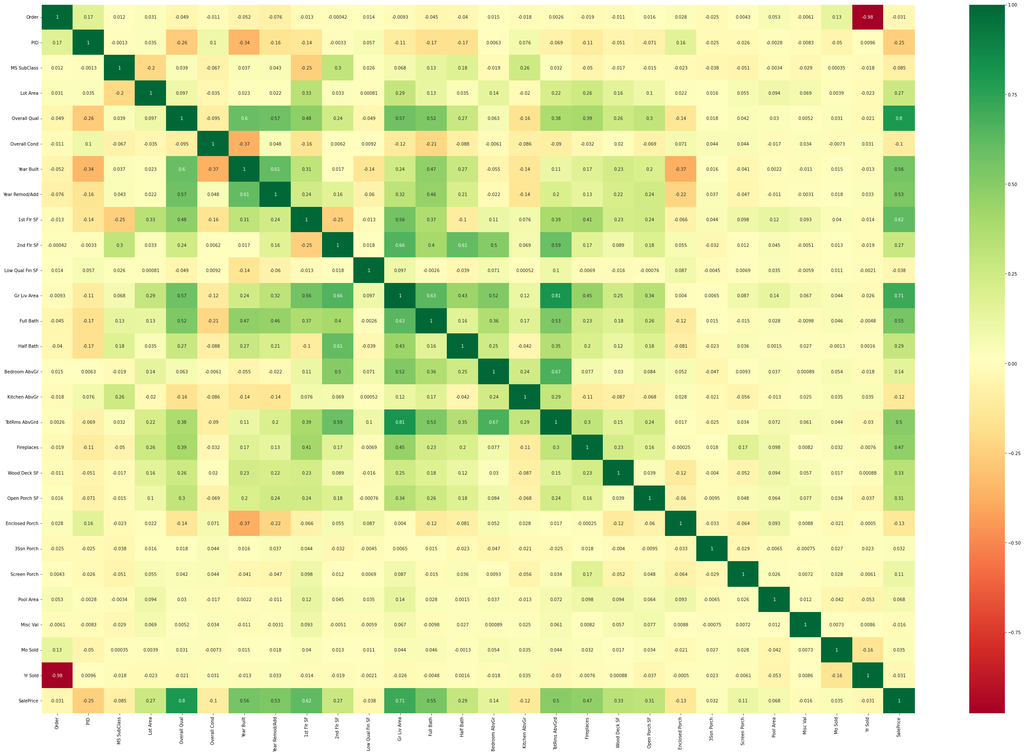

```python
plt.figure(figsize=(45,30))
sns.heatmap(df.corr() , annot=True , cmap='RdYlGn')
plt.show()
```

**Drop the Unnecessary Columns**

```python
df.columns
```

```
Index(['Order', 'PID', 'MS SubClass', 'MS Zoning', 'Lot Area', 'Street',
       'Lot Shape', 'Land Contour', 'Utilities', 'Lot Config', 'Land Slope',
       'Neighborhood', 'Condition 1', 'Condition 2', 'Bldg Type',
       'House Style', 'Overall Qual', 'Overall Cond', 'Year Built',
       'Year Remod/Add', 'Roof Style', 'Roof Matl', 'Exterior 1st',
       'Exterior 2nd', 'Exter Qual', 'Exter Cond', 'Foundation', 'Heating',
       'Heating QC', 'Central Air', '1st Flr SF', '2nd Flr SF',
       'Low Qual Fin SF', 'Gr Liv Area', 'Full Bath', 'Half Bath',
       'Bedroom AbvGr', 'Kitchen AbvGr', 'Kitchen Qual', 'TotRms AbvGrd',
       'Functional', 'Fireplaces', 'Paved Drive', 'Wood Deck SF',
       'Open Porch SF', 'Enclosed Porch', '3Ssn Porch', 'Screen Porch',
       'Pool Area', 'Misc Val', 'Mo Sold', 'Yr Sold', 'Sale Type',
       'Sale Condition', 'SalePrice'],
      dtype='object')
```

Drop The Unnecessary Columns

```python
df=df.drop(['Order','Street','Mo Sold','Pool Area','3Ssn Porch','Utilities','Land Contour','PID','Lot Shape','Sale Type','Lot Config','Condition 1','Condition 2','Yr Sold','Misc Val','Enclosed Porch','MS SubClass','MS Zoning','House Style','Exterior 1st','Heating','2nd Flr SF'], axis=1)
```

```python
df.shape
```

```
(2930, 33)
```

```python
#Without the target variables
x=df.drop(['SalePrice'] , axis=1)
#Target Variable
y=df['SalePrice']
```

```python
print(x.shape)
print(y.shape)
```

```
(2930, 32)
(2930,)
```

Visualization of Insights.

- Plotting Scatter graph.
- Histogram of years houses were built.
- Histogram of years when houses were sold.
- Distribution of Sale Price value.
- Visualization of the relation among Sale Price, Year_Built, and Year_Sold.

```python
x.columns
```

```
Index(['Lot Area', 'Land Slope', 'Neighborhood', 'Bldg Type', 'Overall Qual',
       'Overall Cond', 'Year Built', 'Year Remod/Add', 'Roof Style',
       'Roof Matl', 'Exterior 2nd', 'Exter Qual', 'Exter Cond', 'Foundation',
       'Heating QC', 'Central Air', '1st Flr SF', 'Low Qual Fin SF',
       'Gr Liv Area', 'Full Bath', 'Half Bath', 'Bedroom AbvGr',
       'Kitchen AbvGr', 'Kitchen Qual', 'TotRms AbvGrd', 'Functional',
       'Fireplaces', 'Paved Drive', 'Wood Deck SF', 'Open Porch SF',
       'Screen Porch', 'Sale Condition'],
      dtype='object')
```

**Plot The Scatter Graph among Dataset**

To Draw the Scatter Graph Between Target Variable(Sale Price) and Strong Postive Covariance Variables or Strong Negative Covarriance Variables.

Sale Price Maximum is greater then 70000

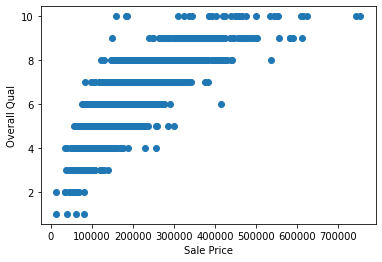

```python
#plot the Scatter Graph of Overall Qual & Sale Price
plt.scatter(y,df['Overall Qual'])
plt.xlabel('Sale Price')
plt.ylabel('Overall Qual')
plt.show()
```

To Draw the Scatter Graph Between Target Variable(Sale Price) and Strong Postive Covariance Variables or Strong Negative Covarriance Variables.

Sale Price Maximum is greater then 70000 when 1st Flr SF is greater than 2000

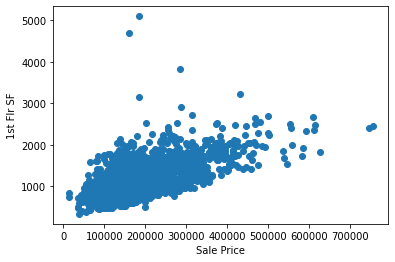

```python
#plot the Scatter Graph of 1st Flr SF & Sale Price
plt.scatter(y,df['1st Flr SF'])
plt.xlabel('Sale Price')
plt.ylabel('1st Flr SF')
plt.show()
```

To Draw the Scatter Graph Between Target Variable(Sale Price) and Strong Postive Covariance Variables or Strong Negative Covarriance Variables.

Sale Price Maximum is greater then 70000 when Gr Liv Area is greater than 4000 And Other Variables can also show maximum sale price >700000

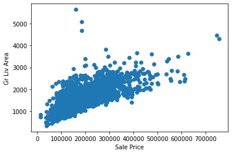

```python
plt.scatter(y,df['Gr Liv Area'])
plt.xlabel('Sale Price')
plt.ylabel('Gr Liv Area')
plt.show()
```

To Draw the Scatter Graph Between Target Variable(Sale Price) and Strong Postive Covariance Variables or Strong Negative Covarriance Variables.

Sale Price Maximum is greater then 700000 when Sale Condition is normal and Abnormal regarding given dataset

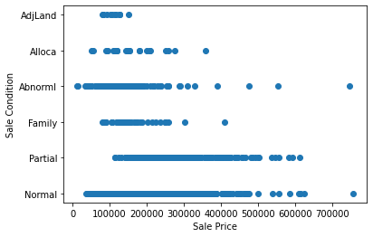

```python
plt.scatter(y,df['Sale Condition'])
plt.xlabel('Sale Price')
plt.ylabel('Sale Condition')
plt.show()
```

To Draw the Scatter Graph Between Target Variable(Sale Price) and Strong Postive Covariance Variables or Strong Negative Covarriance Variables.

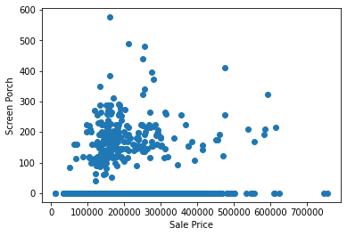

```python
plt.scatter(y,df['Screen Porch'])
plt.xlabel('Sale Price')
plt.ylabel('Screen Porch')

plt.show()
```

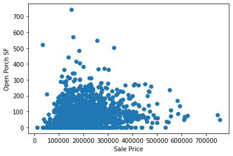

```python
plt.scatter(y,df['Open Porch SF'])
plt.xlabel('Sale Price')
plt.ylabel('Open Porch SF')
plt.show()
```

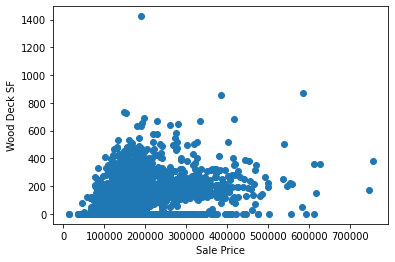

```python
plt.scatter(y,df['Wood Deck SF'])
plt.xlabel('Sale Price')
plt.ylabel('Wood Deck SF')
plt.show()
```

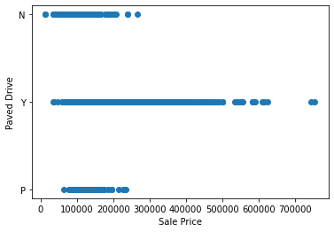

```python
plt.scatter(y,df['Paved Drive'])
plt.xlabel('Sale Price')
plt.ylabel('Paved Drive')
plt.show()
```

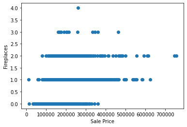

```python
plt.scatter(y,df['Fireplaces'])
plt.xlabel('Sale Price')
plt.ylabel('Fireplaces')
plt.show()
```

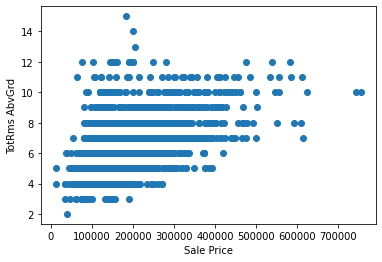

```python
plt.scatter(y,df['TotRms AbvGrd'])
plt.xlabel('Sale Price')
plt.ylabel('TotRms AbvGrd')
plt.show()
```

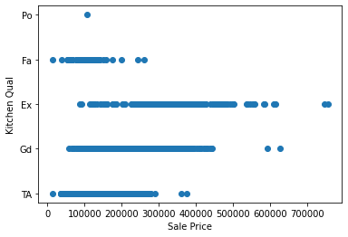

```python
plt.scatter(y,df['Kitchen Qual'])
plt.xlabel('Sale Price')
plt.ylabel('Kitchen Qual')
plt.show()
```

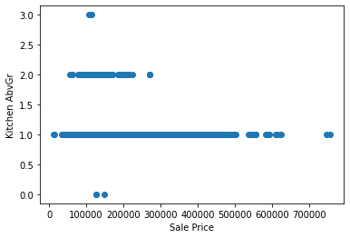

```python
plt.scatter(y,df['Kitchen AbvGr'])
plt.xlabel('Sale Price')
plt.ylabel('Kitchen AbvGr')
plt.show()
```

**Histrogram**

To Plot the Histrogram of Each variable in given dataset

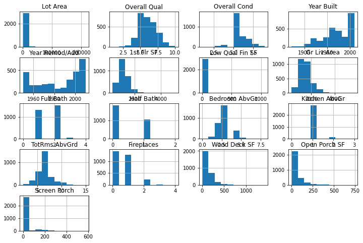

```python
x.hist(figsize=(12,8))
plt.show()
```